# DS-310 Semester Project

Samantha Cotton

2026-10-05

## Introduction

From hair color to height, eye color to dimples, many of the characteristics of humans (and almost every living organism on Earth) are determined by our genetics. Beyond even our physical characteristics, our genes code for less apparent traits, such as higher risks for certain medical conditions like heart disease or high blood pressure. There is a nearly infinite amount of variation in the human genome that contributes to these differences, created by millions of years of evolution. One driving factor in the evolution of our genetics are *mutations*, or changes, in our genetic code, that can be harmful (deleterious), with many of these causing genetic disorders, such as cystic fibrosis, through the loss of function of (or wrong expression of) a protein. However, mutations can also have no real, noticeable affect (neutral mutations); these neutral mutations slowly accummulate across populations, and lead to the variations between humans that we see today!

One of the reasons that neutral mutations can remain in the genome of an organism and be passed down is due to the **mutational robustness** of proteins; **mutational robustness** can be defined (in this instance) as a protein structure’s ability to absorb sequence changes, or mutations, without its stability, shape/structure, or function being changed or affected by the mutation. But what characteristics of a protein enable it to have high mutational robustness? How do you even quantify mutational robustness? Researchers Srijita Acharaya and Sucharita Dey conducted a recent study to evaluate these questions, and provided public access to their collected data, which I was able to find through **Figshare.**

**Dataset:** https://figshare.com/ndownloader/articles/33588613/versions/1,

**Dataset Source:** https://figshare.com/articles/dataset/_b_Protein_size_geometry_and_oligomeric_state_shape_mutational_robustness_b_/33588613?file=68432056.

The data was split across four separate datasets, where each observation in each dataset represented a specific protein, and each column represented a certain characteristic of the protein. The datasets were separated by type of subunit, or amino acid sequence/chain (i.e., building blocks), of a protein structure. Though the data was collected across multiple different datasets, the variables were almost exactly the same across all sets, with a few minor variations. A **codebook** is provided below.

[output not shown]

From these variables, it is hard to tell how exactly mutational robustness will be evaluated, analyzed, and predicted. To evaluate and identify whether a protein structure exhibits robustness to mutations, one of the variables, `foldseek_family_size`, also contains the *sequences* of each of the similar/matched protein structures; in this case, a large(er) family size of a particular protein structure indicates many protein structures that, because they have near-similar structures, therefore have similar shape, function, and stability. The reasoning follows that these protein structures that have large(er) family sizes, because they have similar shape, function, and stability while having many varied sequences of amino acids/genes between them, indicates these protein structures can tolerate more variance (mutations!) in amino acid/genetic sequencing, and are thus mutationally robust. Though not a perfectly direct measure of mutational robustness, it is still a variable that can be very helpful in further predictions and inferences of mutational robustness when given a protein structure.

The authors of this dataset, researchers in the field of bioinformatics, have narrowed down key characteristics (variables) that can significantly contribute to mutational robustness of a protein structure. These variables include protein size and length, number of subunits, internal packing/compactness, shape of the protein (by looking at overall surface irregularity), and location of hydrogen bonds within the protein. Using these characteristics, as well as exploring other possible contributing or confounding variables in this dataset, such as `Function_Class` or `surf_area_vol_ratio`, I hope to evaluate the relationship between *all* of these variables and family size of a protein structure, to first infer how the variables contribute to the structures’ mutational robustness, and to then be able to **predict** mutational robustness of a protein structure using the results of my findings from this dataset.

### Data Wrangling

After reading in the four datasets, I first wanted to use the `glimpse()` function to look at each dataset’s number of rows and columns, data types for each variable, and spot any variations between variable names that could impact the data wrangling and exploratory analysis steps.

```
## Rows: 11,076
## Columns: 23
## $ code                          <chr> "16pk_1", "1914_1", "1a0i_1", "1a0p_1", …
## $ nsub2                         <dbl> 1, 1, 1, 1, 1, 1, 1, 1, 1, 1, 1, 1, 1, 1…
## $ sym                           <chr> "NPS", "NPS", "NPS", "NPS", "NPS", "NPS"…
## $ accession                     <chr> "P07378", "P16254", "P00969", "P0A8P8", …
## $ resol                         <dbl> 1.58, 2.53, 2.60, 2.50, 2.35, 2.10, 2.10…
## $ length_full                   <dbl> 415, 232, 348, 290, 219, 591, 88, 177, 2…
## $ Organism                      <chr> "Trypanosoma brucei brucei", "Mus muscul…
## $ foldseek_family_size          <dbl> 992, 169, 5, 86, 19, 342, 429, 153, 277,…
## $ blast_hits_cov80_eval01_uni50 <dbl> 31, 46, 5, 124, 4, 97, 195, 314, 12, 120…
## $ compactness                   <dbl> 3.44, 2.94, 3.05, 3.15, 2.68, 2.77, 1.34…
## $ surf_area_vol_ratio           <dbl> 0.23, 0.36, 0.27, 0.29, 0.33, 0.22, 0.47…
## $ Intrasubunit_HBonds.1         <dbl> 301, 103, 202, 201, 108, 313, 58, 109, 1…
## $ contact_density_3.5A          <dbl> 2.11, 1.82, 1.86, 2.32, 1.39, 2.03, 2.27…
## $ contact_density_4A            <dbl> 3.31, 2.88, 3.05, 3.14, 2.46, 3.08, 2.92…
## $ contact_density_4.5A          <dbl> 3.97, 3.56, 3.70, 3.73, 3.37, 3.63, 3.12…
## $ contact_density_vdw           <dbl> 2.87, 2.46, 2.57, 2.79, 1.95, 2.67, 2.64…
## $ core_hydrophobicity           <dbl> 1.18, 1.29, 1.05, 1.16, 0.80, 0.54, 1.59…
## $ VDW_Volume                    <dbl> 67807.23, 26197.50, 53433.64, 42596.33, …
## $ Surface_Dist_StdDev           <dbl> 7.20, 5.09, 8.19, 6.36, 9.35, 8.44, 6.92…
## $ core_residues                 <dbl> 233, 77, 163, 134, 83, 252, 19, 94, 150,…
## $ surface_residues              <dbl> 182, 94, 169, 137, 111, 239, 65, 83, 115…
## $ surface_area                  <dbl> 15456.95, 9378.21, 14427.17, 12515.43, 1…
## $ Function_Class                <chr> "Enzyme", "Regulatory", "Enzyme", "Regul…
```

```
## Rows: 9,183
## Columns: 24
## $ code                          <chr> "2rcd_3", "4lh4_1", "3bqx_1", "5fpz_1", …
## $ chain_name                    <chr> "D", "A", "A", "A", "A", "B", "A", "A", …
## $ nsub2                         <dbl> 2, 2, 2, 2, 2, 2, 2, 2, 2, 2, 2, 2, 2, 2…
## $ sym                           <chr> "C2", "C2", "C2", "C2", "C2", "C2", "C2"…
## $ accession                     <chr> "Q6D1E8", "Q9WJM2", "Q0G7J9", "A1JMF7", …
## $ resol                         <dbl> 2.320, 1.800, 1.320, 1.500, 2.000, 1.600…
## $ length_full                   <dbl> 129, 182, 150, 110, 91, 90, 138, 142, 21…
## $ Organism                      <chr> "Pectobacterium atrosepticum (strain SCR…
## $ foldseek_family_size          <dbl> 536, 14, 922, 366, 406, 10, 852, 860, 84…
## $ blast_hits_cov80_eval01_uni50 <dbl> 44, 36, 14, 11, 20, 1194, 121, 126, 75, …
## $ compactness                   <dbl> 2.16, 1.94, 1.39, 1.68, 1.23, 0.58, 2.29…
## $ surf_area_vol_ratio           <dbl> 0.19, 0.21, 0.15, 0.17, 0.21, 0.15, 0.20…
## $ Intrasubunit_HBonds           <dbl> 166, 184, 166, 140, 104, 102, 174, 171, …
## $ contact_density_3.5A          <dbl> 1.89, 2.12, 1.78, 1.63, 1.91, 2.16, 2.06…
## $ contact_density_4A            <dbl> 3.04, 3.15, 2.92, 2.92, 2.92, 3.00, 3.32…
## $ contact_density_4.5A          <dbl> 3.66, 3.88, 3.78, 3.70, 3.65, 3.54, 3.93…
## $ contact_density_vdw           <dbl> 2.51, 2.78, 2.47, 2.35, 2.47, 2.64, 2.82…
## $ core_hydrophobicity           <dbl> 0.98, 2.14, 1.59, 0.09, 1.92, 0.20, 1.61…
## $ VDW_Volume                    <dbl> 37101.20, 40188.26, 41638.99, 35662.40, …
## $ Surface_Dist_StdDev           <dbl> 4.08, 3.47, 3.93, 3.37, 3.67, 3.42, 4.47…
## $ core_residues                 <dbl> 80, 78, 58, 60, 30, 12, 101, 102, 67, 84…
## $ surface_residues              <dbl> 86, 98, 84, 72, 52, 29, 99, 100, 95, 78,…
## $ surface_area                  <dbl> 6933.06, 8475.38, 6230.05, 5908.00, 5191…
## $ Function_Class                <chr> "Other", "Enzyme", "Other", "Other", "En…
```

```
## Rows: 780
## Columns: 24
## $ code                          <chr> "1a88_1", "1a8q_2", "1a8s_3", "1af6_1", …
## $ chain_name                    <chr> "A", "A", "A", "A", "A", "A", "A", "A", …
## $ nsub2                         <dbl> 3, 3, 3, 3, 3, 3, 3, 3, 3, 3, 3, 3, 3, 3…
## $ sym                           <chr> "C3", "C3", "C3", "C3", "C3", "C3", "C3"…
## $ accession                     <chr> "P49323", "P33912", "O31158", "P02943", …
## $ resol                         <dbl> 1.90, 1.75, 1.80, 2.40, 1.50, 3.00, 2.00…
## $ length_full                   <dbl> 275, 274, 273, 421, 277, 233, 196, 180, …
## $ Organism                      <chr> "Streptomyces lividans", "Kitasatospora …
## $ foldseek_family_size          <dbl> 960, 1038, 990, 114, 967, 230, 125, 947,…
## $ blast_hits_cov80_eval01_uni50 <dbl> 6437, 8312, 7679, 275, 7871, 3957, 231, …
## $ compactness                   <dbl> 3.46, 3.67, 3.63, 2.82, 3.62, 2.87, 2.85…
## $ surf_area_vol_ratio           <dbl> 0.49, 0.44, 0.46, 0.51, 0.44, 0.50, 0.49…
## $ Intrasubunit_HBonds           <dbl> 559, 576, 564, 902, 591, 445, 492, 359, …
## $ contact_density_3.5A          <dbl> 4.21, 4.27, 4.20, 4.01, 4.13, 3.78, 4.02…
## $ contact_density_4A            <dbl> 3.63, 3.50, 3.41, 3.08, 3.41, 3.10, 3.55…
## $ contact_density_4.5A          <dbl> 4.21, 4.27, 4.20, 4.01, 4.13, 3.78, 4.02…
## $ contact_density_vdw           <dbl> 3.10, 2.95, 2.98, 2.47, 2.86, 2.62, 3.24…
## $ core_hydrophobicity           <dbl> 0.63, 0.69, 0.75, -0.59, 1.04, 1.29, 0.8…
## $ VDW_Volume                    <dbl> 124968.73, 122641.32, 121790.80, 193942.…
## $ Surface_Dist_StdDev           <dbl> 4.71, 5.20, 4.73, 7.84, 4.55, 7.24, 4.50…
## $ core_residues                 <dbl> 432, 450, 442, 546, 447, 269, 261, 196, …
## $ surface_residues              <dbl> 263, 228, 264, 432, 246, 190, 210, 204, …
## $ surface_area                  <dbl> 20592.76, 19091.89, 20409.15, 33017.28, …
## $ Function_Class                <chr> "Enzyme", "Enzyme", "Enzyme", "Transport…
```

```
## Rows: 2,147
## Columns: 26
## $ code                          <chr> "1a0d_1", "1a0e_1", "1a2z_1", "1a3x_1", …
## $ chain_name                    <chr> "A", "A", "A", "A", "A", "A", "A", "A", …
## $ nsub2                         <dbl> 4, 4, 4, 4, 4, 4, 4, 4, 4, 4, 4, 4, 4, 4…
## $ sym                           <chr> "D2", "D2", "D2", "D2", "D2", "D2", "D2"…
## $ accession                     <chr> "P54273", "P45687", "O07883", "P00549", …
## $ resol                         <dbl> 3.00, 2.70, 1.70, 3.00, 2.35, 2.10, 2.10…
## $ length_full                   <dbl> 440, 443, 220, 500, 488, 503, 319, 152, …
## $ Organism                      <chr> "Geobacillus stearothermophilus (Bacillu…
## $ foldseek_family_size          <dbl> 952, 993, 1028, 1006, 864, 1006, 904, 28…
## $ blast_hits_cov80_eval01_uni50 <dbl> 55, 54, 492, 1543, 317, 6325, 1158, 231,…
## $ compactness                   <dbl> 2.67, 2.76, 2.86, 3.52, 2.47, 3.43, 3.05…
## $ surf_area_vol_ratio           <dbl> 0.11, 0.11, 0.15, 0.17, 0.10, 0.14, 0.17…
## $ Intrasubunit_HBonds           <dbl> 1228, 1300, 582, 1194, 1173, 1357, 932, …
## $ contact_density_3.5A          <dbl> 4.11, 4.09, 4.37, 3.94, 4.20, 4.19, 4.05…
## $ contact_density_4A            <dbl> 3.50, 3.47, 3.70, 3.25, 3.57, 3.47, 3.29…
## $ contact_density_4.5A          <dbl> 4.11, 4.09, 4.37, 3.94, 4.20, 4.19, 4.05…
## $ contact_density_vdw           <dbl> 3.02, 3.03, 3.26, 2.78, 3.11, 3.01, 2.84…
## $ core_hydrophobicity           <dbl> 0.74, 0.59, 1.15, 0.97, 0.39, 1.01, 1.70…
## $ VDW_Volume                    <dbl> 264326.22, 265823.42, 140365.05, 277571.…
## $ Surface_Dist_StdDev           <dbl> 8.32, 8.77, 5.43, 6.98, 9.20, 8.33, 6.56…
## $ core_residues                 <dbl> 705, 734, 402, 976, 767, 1009, 568, 209,…
## $ surface_residues              <dbl> 358, 362, 245, 586, 398, 502, 356, 178, …
## $ surface_area                  <dbl> 29317.07, 29917.48, 21156.64, 47566.26, …
## $ Function_Class                <chr> "Enzyme", "Enzyme", "Enzyme", "Enzyme", …
## $ PDB_ID                        <chr> "1A0D", "1A0E", "1A2Z", "1A3X", "1A4E", …
## $ Entity_ID                     <dbl> 1, 1, 1, 1, 1, 1, 1, 1, 1, 2, 1, 1, 1, 1…
```

After combing through each dataset, I spotted a slight variation in the variable `Intrasubunit_HBonds` in the `monomer` data frame compared to the other three; it was recorded as `Intrasubunit_HBond.1` instead. Using the `rename()` function from `**dplyr**`, I matched the variable names so that the variable matched across all the datasets!

However, there were some variables that had more glaring variations between the datasets than the problem mentioned above. The `chain_name` variable does not appear in the `monomer` dataset and thus has no values for that variable; in order to join these data sets together, one thing to do would be to have the same variables across all the datasets; therefore, my next step was to add the `chain_name` variable to the `monomer` dataset, and place NA’s as its values.

The final visible variation across the four datasets was the appearance of two variables in the `homotetramer` dataset that do not appear in the other three; the variables `PDB_ID` and `Entity_ID`. After some investigating, I concluded that these two additional variables were unnecessary and redundant to keep, as the values in those variables were already recorded in the values of the `code` variable. After removing those two variables, I was finally able to join the datasets together into one!

Once I had the joined the datasets together, I noticed that the `nsub2` variable was redundant and unnecessary to keep, since once I added a column classifying each row as a monomer, homodimer, homotrimer, or homotetramer, those classifications would already inform the reader of the number of subunits in the protein structure. Therefore, once I had used the variable to create the `subunit_type` variable, I removed it from the joined dataset, as well as moved some identifier variables to the front.

Lastly, I need to check for any missing values in my completed dataset; while I know that there will be some for the `chain_name` variable for the `monomer` subunit type, I want to check and make sure there are no other missing values I am not catching; to do this, I will use the `colSums()` function!

```
##                          code                    chain_name
##                             0                         11076
##                  subunit_type                           sym
##                             0                             0
##                     accession                         resol
##                             0                             0
##                   length_full                      Organism
##                             0                             0
##          foldseek_family_size blast_hits_cov80_eval01_uni50
##                             0                             0
##                   compactness           surf_area_vol_ratio
##                             0                             0
##           Intrasubunit_HBonds          contact_density_3.5A
##                             0                             0
##            contact_density_4A          contact_density_4.5A
##                             0                             0
##           contact_density_vdw           core_hydrophobicity
##                             0                             0
##                    VDW_Volume           Surface_Dist_StdDev
##                             0                             3
##                 core_residues              surface_residues
##                             0                             0
##                  surface_area                Function_Class
##                             0                             0
```

From this step, we can see that we got the 11,076 missing values of our `monomer` subunit type in the `chain_name` variable, but the missing values in the `Surface_Dist_StdDev` variable were unexpected! As we continue on to the Exploratory Data Analysis, it would be wise to keep this in the back of our minds as we explore the data, plot relationships between variables, and calculate summary statistics.

And now I’m ready to start exploring the data!

## Exploratory Data Analysis

#### Exploring Subunit Type

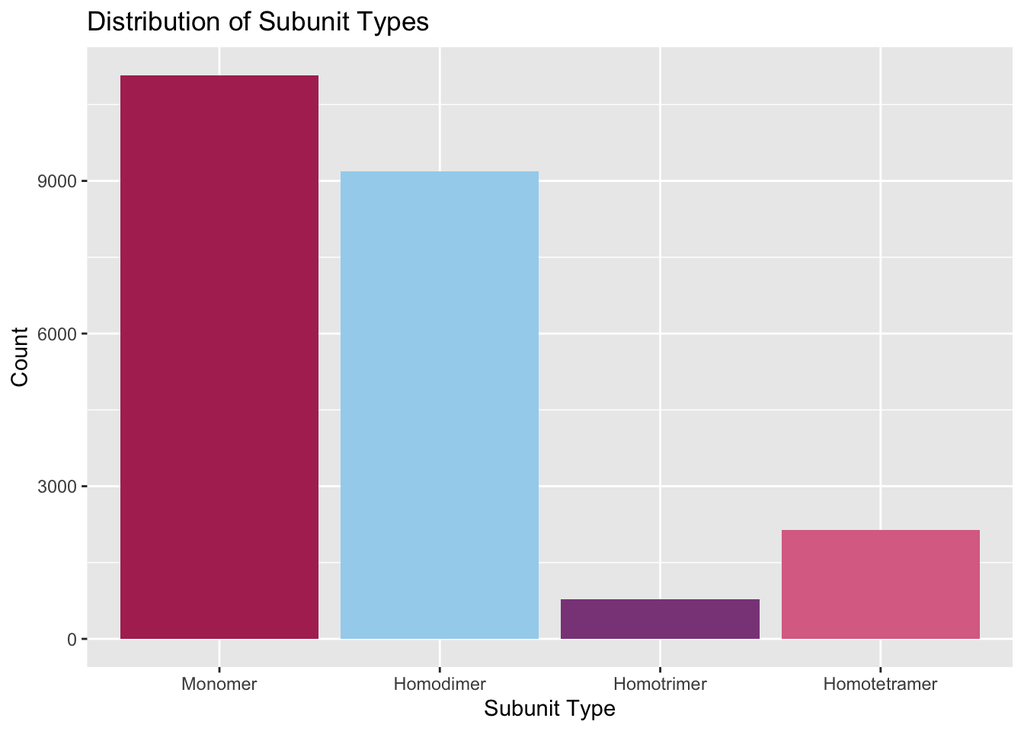

After releveling the `subunit_type` variable to order the subunit types in ascending order (Monomer first with one subunit, Homodimer second with two subunits, and so on) for clarity, I generated a bar chart to display the count of each type of subunit structure within the data set. From this visualization, it appears the Monomer structure has the most observations in this dataset, and the Homotrimer has the least; the Homotetramer type has the second lowest, and the Homodimer type has the second highest, with a dramatic difference in count (when looking at range) between the two highest counts and the two lowest.

```r
proteins %>%
  count(subunit_type) %>%
  mutate(type_perc = n / sum(n)) %>%
  mutate(type_perc = round(type_perc, digits = 3))
```

```
## # A tibble: 4 × 3
##   subunit_type     n type_perc
##   <fct>        <int>     <dbl>
## 1 Monomer      11076     0.478
## 2 Homodimer     9183     0.396
## 3 Homotrimer     780     0.034
## 4 Homotetramer  2147     0.093
```

The table above supports this claim, as the Monomer type has the highest count in the dataset at 11,076 observations and accounts for 47.8% of the data, while the Homotrimer type has the lowest count of observations at 780, accounting for only 3.4% of the data.

#### Protein Function Analysis

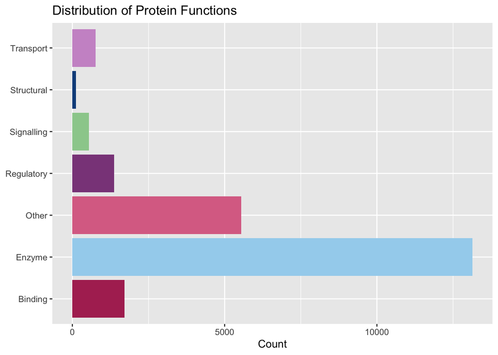

The Enzyme functional proteins have the most observations in the dataset, followed by “Other” functional proteins at the second highest observations. Structural functional proteins have the least amount of observations in the dataset, followed by Signaling functional proteins at the second lowest amount. There is a dramatic difference in count between the most common functional protein in this dataset, the Enzyme, and the least common, the Structural.

#### Distribution of Family Size

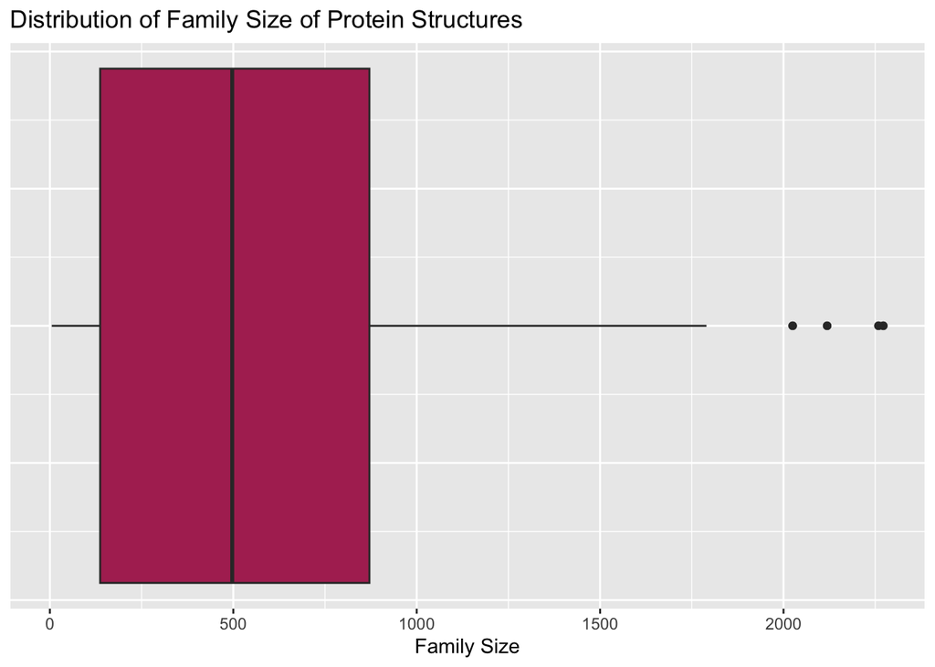

```
## # A tibble: 1 × 6
##   median_size    Q1    Q3   IQR max_size min_size
##         <dbl> <dbl> <dbl> <dbl>    <dbl>    <dbl>
## 1         497   137   871   734     2272        5
```

The distribution of family size is symmetrical, if slightly right-skewed, with some high outliers. The distribution has a median family size of 497 similar matches for a specified protein structure; the spread of the distribution (when looking at IQR) is 734 matches.

#### Distribution of Compactness

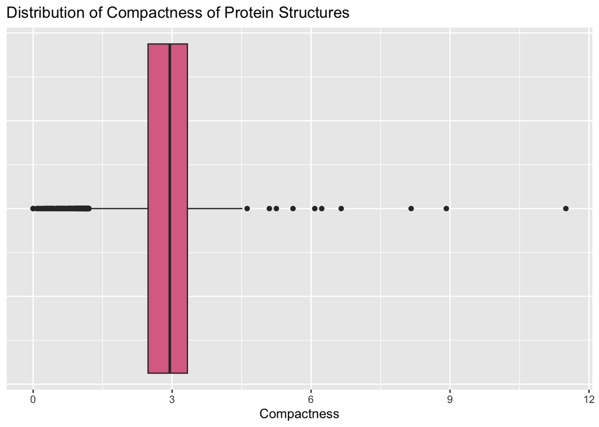

```
## # A tibble: 1 × 6
##   median_compactness    Q1    Q3   IQR max_compactness min_compactness
##                <dbl> <dbl> <dbl> <dbl>           <dbl>           <dbl>
## 1               2.95  2.48  3.33  0.85            11.5               0
```

The distribution of compactness is somewhat symmetrical, if slightly right-skewed, with high outliers on both sides of the distribution; the median compactness ratio/proportion (it is unclear how it was measured in the original dataset) is 2.95, with a spread (in terms of IQR) of 0.85; visually, its spread is smaller compared to the IQR (spread) of family size.

#### Distribution of Contact Density in VDW Radii of Atoms

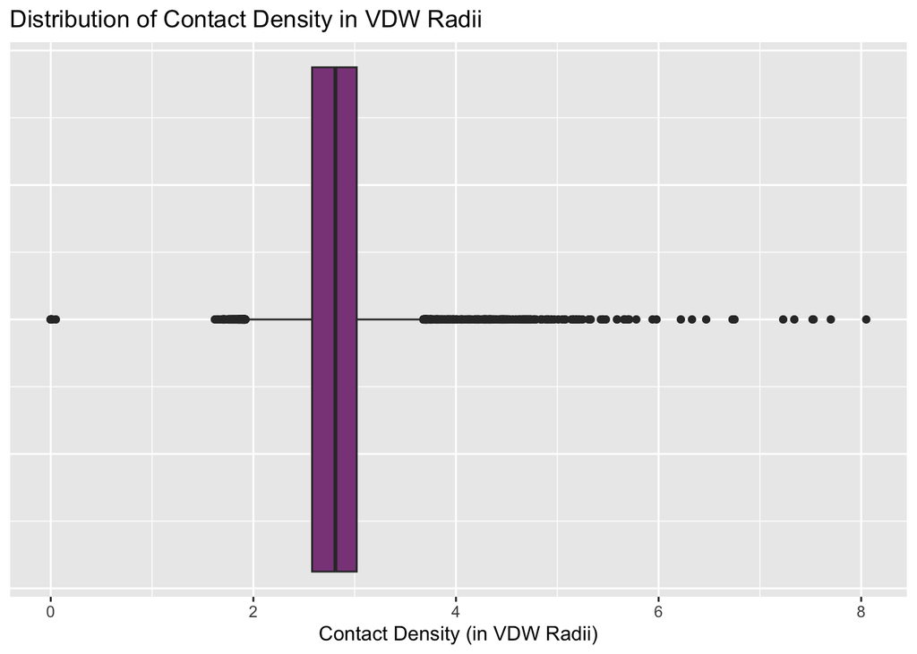

```
## # A tibble: 1 × 6
##   median_contact_vdw    Q1    Q3   IQR max_contact_dn_vdw min_contact_dn_vdw
##                <dbl> <dbl> <dbl> <dbl>              <dbl>              <dbl>
## 1               2.81  2.58  3.02  0.44               8.05                  0
```

The distribution of contact density (in terms of VDW Radii of an atom) is right-skewed with high outliers on both sides of the distribution, but more following the right tail of the plot; the median contact density (in terms of VDW Radii) is 2.81, with a spread (in terms of IQR) of 0.44; visually, its spread is smaller compared to the IQR (spread) of family size and compactness.

**Note!** I decided to analyze contact density using the VDW radii of atoms calculation (which uses angstrom as units), just because this calculation accounts for the sizes and repulsion forces between different atoms within a protein structure, whereas the other contact density measurements are arbitrary distances to separate “close” atoms and “farther away” atoms; additionally, four different measurements of contact density is unneccessary (in this instance) and can quickly clutter visualizations and graphs further on.

#### Distribution of Surface Irregularity

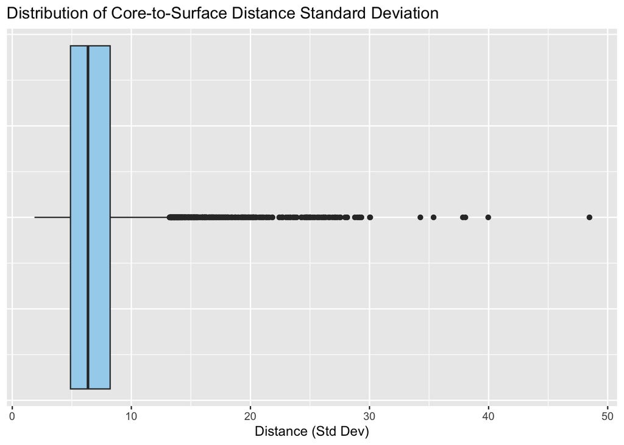

```
## # A tibble: 1 × 6
##   median_dist_stddev    Q1    Q3   IQR max_dist_stddev min_dist_stddev
##                <dbl> <dbl> <dbl> <dbl>           <dbl>           <dbl>
## 1               6.36  4.89  8.22  3.33            48.5            1.87
```

The distribution of surface irregularity (in terms of core-to-surface distance standard deviation) is right-skewed with high outliers on the right end of the plot; the median distance standard deviation is 6.36, with a spread (in terms of IQR) of 3.33; visually, its spread is smaller compared to the IQR (spread) of family size.

#### Distribution of Length

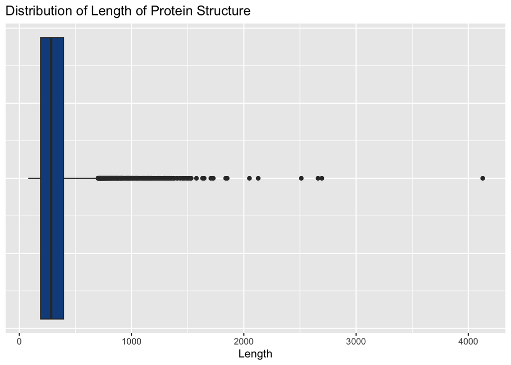

```
## # A tibble: 1 × 6
##   median_length    Q1    Q3   IQR max_length min_length
##           <dbl> <dbl> <dbl> <dbl>      <dbl>      <dbl>
## 1           285   190   394   204       4128         80
```

#### Distribution of Intrasubunit Hydrogen Bonds

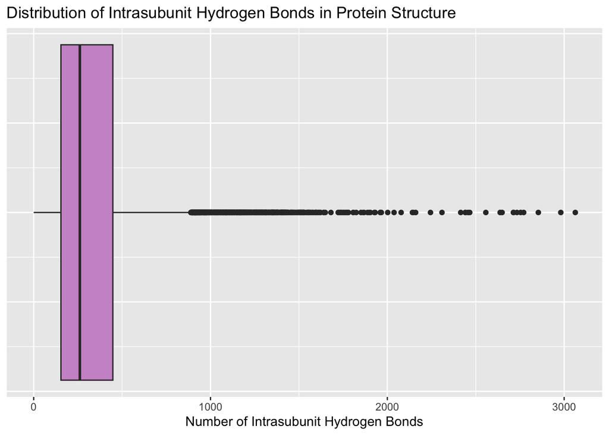

```
## # A tibble: 1 × 6
##   median_hbonds    Q1    Q3   IQR max_hbonds min_hbonds
##           <dbl> <dbl> <dbl> <dbl>      <dbl>      <dbl>
## 1           261   154  448.  294.       3063          0
```

The distribution of intrasubunit hydrogen bonds is right-skewed with several high outliers on the right end of the plot; the median amount of hydrogen bonds of a protein structure is 261 bonds, with a spread (in terms of IQR) of 293.75 bonds; visually, its spread is smaller compared to the IQR (spread) of family size, but slightly larger than the other analyzed variables above.

#### Size of Protein by Subunit Type

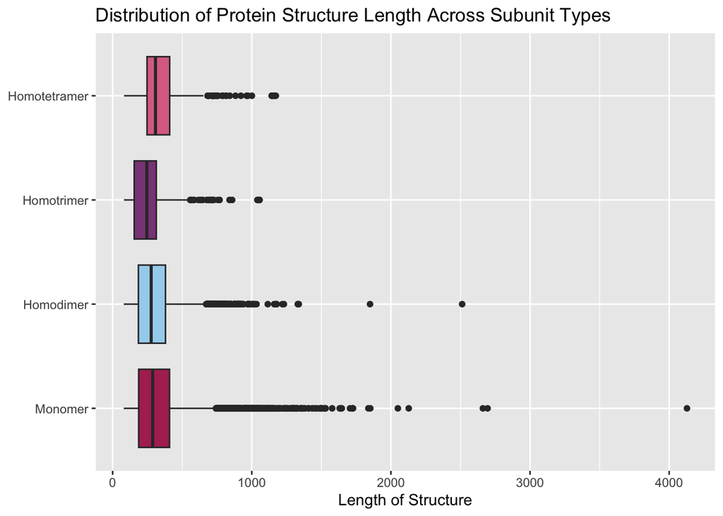

From this visualization, it appears that the Monomer, Homodimer, and Homotetramer subunit types all have roughly similar median lengths (measured in number of amino acids) of their structures, with the Homotrimer type appearing to have the lowest median length. The Monomer type appears to have the largest spread when looking at IQR, while the three other subunit distributions appear to have roughly similar spreads when lookig at IQR. All distributions are right-skewed and have several outliers, with the Monomer distribution having an extremely high outlier.

```r
proteins %>%
  group_by(subunit_type) %>%
  summarize(median_length = median(length_full),
            Q1 = quantile(length_full, probs = 0.25),
            Q3 = quantile(length_full, probs = 0.75),
            IQR = Q3 - Q1,
            max_length = max(length_full),
            min_length = min(length_full))
```

```
## # A tibble: 4 × 7
##   subunit_type median_length    Q1    Q3   IQR max_length min_length
##   <fct>                <dbl> <dbl> <dbl> <dbl>      <dbl>      <dbl>
## 1 Monomer               288    187   409   222       4128         80
## 2 Homodimer             277    185   380   195       2512         80
## 3 Homotrimer            246.   155   314   159       1056         81
## 4 Homotetramer          308    247   410   163       1173         82
```

#### Surface Area Across Subunit Type

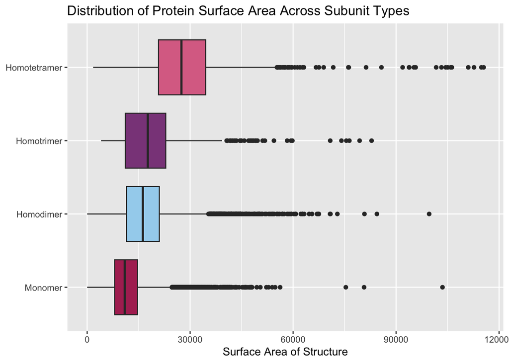

From this visualization, it appears the Homotetramer type has the highest median surface area and largest spread (when looking at IQR) compared to the other subunit types, and the Monomer type appears to have the lowest median surface area and the lowest spread (when looking at IQR). All distributions are right-skewed with several outliers; the Homodimer and Monomer distributions seem to have extremely high outliers as well.

```
## # A tibble: 4 × 7
##   subunit_type median_sf     Q1     Q3    IQR  max_sf min_sf
##   <fct>            <dbl>  <dbl>  <dbl>  <dbl>   <dbl>  <dbl>
## 1 Monomer         10953.  8012. 14693.  6681. 103519.     0
## 2 Homodimer       16220. 11496. 21024.  9527.  99634.     0
## 3 Homotrimer      17659. 11128. 22910. 11782.  82860.  4073.
## 4 Homotetramer    27473. 20789. 34529. 13740. 115505.  1759.
```

The summary statistics above support these conclusions; the Homotetramer type has the highest median surface area at 27,473.35 angstrom squared, as well as the largest spread (when looking at IQR) at 13,739.83 angstrom squared. The Monomer type has the lowest median surface area at 10,952.92 angstrom squared and the lowest spread (IQR) as well, at 6,680.84 angstrom squared; we can also identify its extremely high outlier as a surface area of 103,518.54 angstrom squared.

#### Surface Irregularity Across Subunit Type

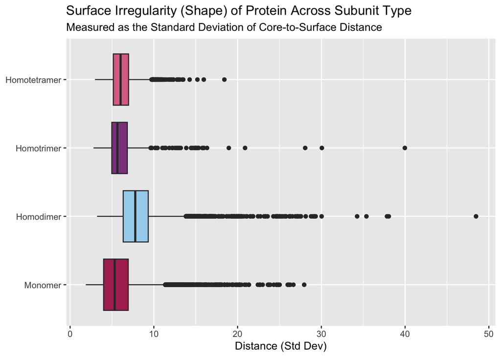

From this visualization, it appears that the Homodimer type has the highest median standard deviation of core-to-surface distance, but seems to have a roughly similar spread (in terms of IQR) to the Monomer type. The Monomer type, interestingly, appears to have the *lowest* median core-to-surface distance standard deviation, though its median seems to be similar to the Homotrimer and Homotetramer types’ medians. All distributions are right-skewed with several outliers, with the Homodimer and Homotrimer (and potentially even the Homotetramer) distributions having extremely high outliers.

```
## # A tibble: 4 × 7
##   subunit_type median_sf    Q1    Q3   IQR max_sf min_sf
##   <fct>            <dbl> <dbl> <dbl> <dbl>  <dbl>  <dbl>
## 1 Monomer          NA     4     6.94  2.94   NA    NA
## 2 Homodimer        NA     6.34  9.33  2.99   NA    NA
## 3 Homotrimer        5.64  4.98  6.83  1.85   40.0   2.79
## 4 Homotetramer      6.03  5.16  6.98  1.82   18.4   2.97
```

The summary statistics cannot adequately support these conclusions; the Homotetramer type has the highest median standard deviation of core-to-surface distance at 6.03 angstrom, as data is missing for the Homodimer and Monomer types. The Homotrimer type has the lowest median distance standard deviation across the four types (at 5.645 angstrom) due to NA’s for the Monomer and Homodimer groups. Interestingly, the Homotetramer has the smallest spread in this table (IQR) at 1.82 angstrom. We can also identify the Homotrimer type’s extremely high outlier of a distance standard deviation of 39.97 angstrom.

#### Subunit Type by Protein Function

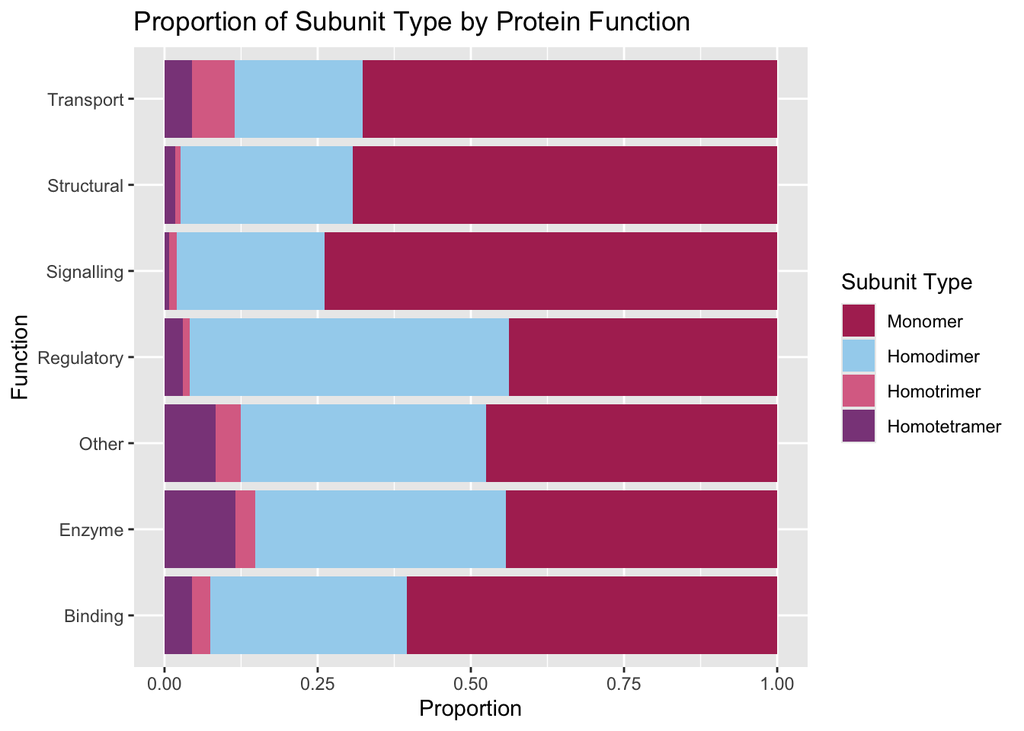

#### Family Size Across Subunit Type

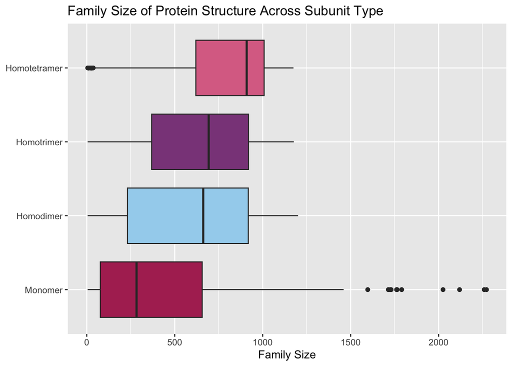

```r
proteins %>%
  group_by(subunit_type) %>%
  summarize(median_fam_size = median(foldseek_family_size),
            Q1 = quantile(foldseek_family_size, probs = 0.25),
            Q3 = quantile(foldseek_family_size, probs = 0.75),
            IQR = Q3 - Q1,
            max_fam_size = max(foldseek_family_size),
            min_fam_size = min(foldseek_family_size))
```

```
## # A tibble: 4 × 7
##   subunit_type median_fam_size    Q1    Q3   IQR max_fam_size min_fam_size
##   <fct>                  <dbl> <dbl> <dbl> <dbl>        <dbl>        <dbl>
## 1 Monomer                  283   77   656   579          2272            5
## 2 Homodimer                662  232.  918   686.         1201            5
## 3 Homotrimer               693  369.  919.  550.         1177            5
## 4 Homotetramer             909  620  1008   388          1175            5
```

#### Analysis of Quantitative Variables

##### Family Size by Length

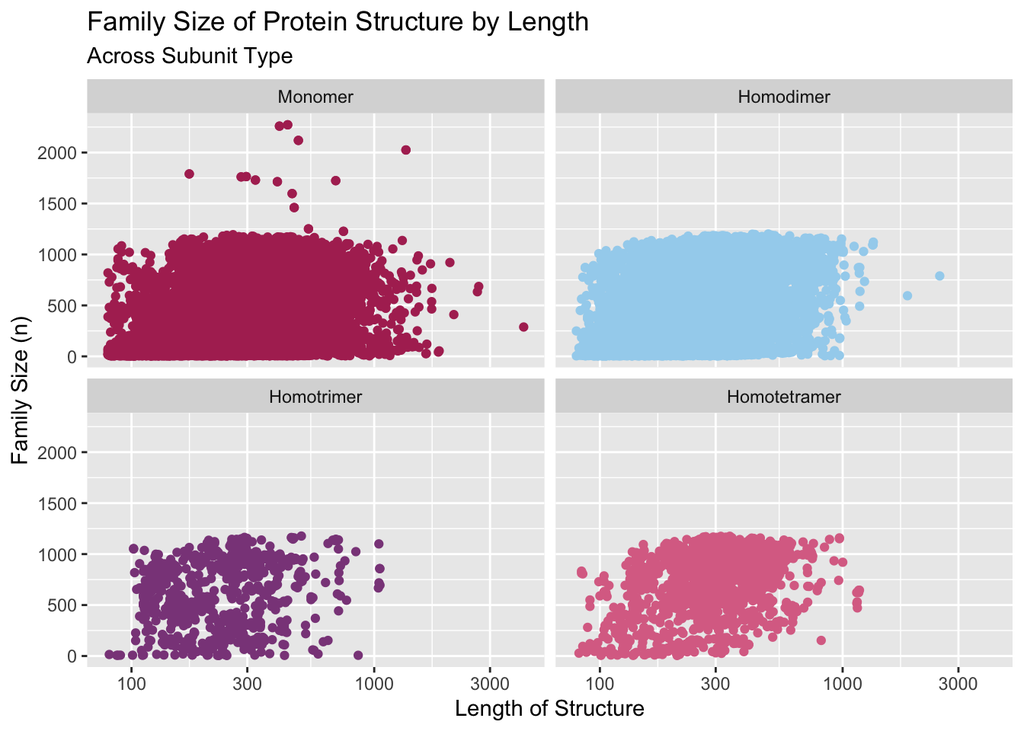

It does not appear that there is a linear relationship or association between length of protein structure and the family size of the protein structure for any of the subunit types.

##### Family Size by Surface Irregularity

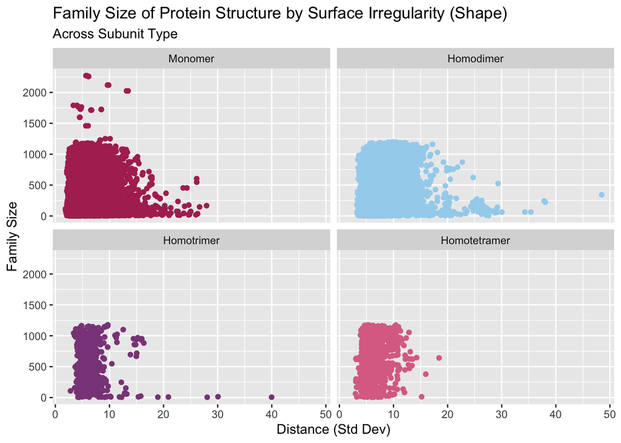

It does not appear that there is a linear relationship or association between the standard deviation of the distance of a protein structure’s core to it’s surface and the family size of the protein structure for any of the subunit types.

##### Family Size by Contact Density

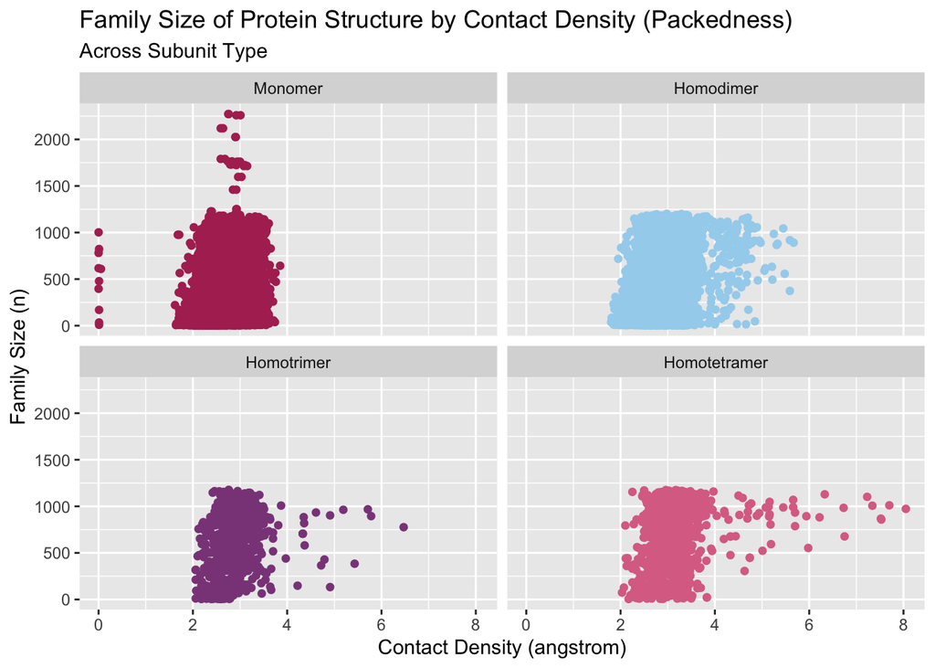

It does not appear that there is a linear relationship or association between the residue-residue contact of a protein structure and the family size of the protein structure for any of the subunit types.

*Note!* I decided to analyze contact density using the VDW radii of atoms calculation, just because this calculation accounts for the sizes and repulsion forces between different atoms within a protein structure!

##### Family Size by Surface Area-to-Volume Ratio

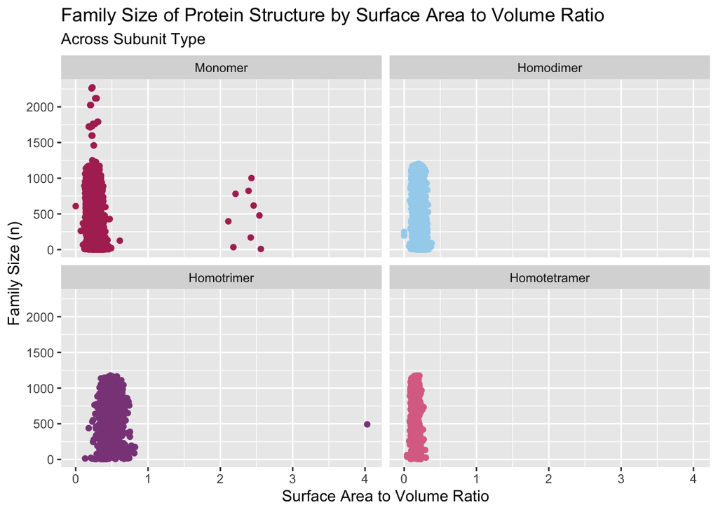

It does not appear that there is a linear relationship or association between the surface area-to-volume ratio of protein structure and the family size of the protein structure for any of the subunit types.

##### Family Size by Compactness

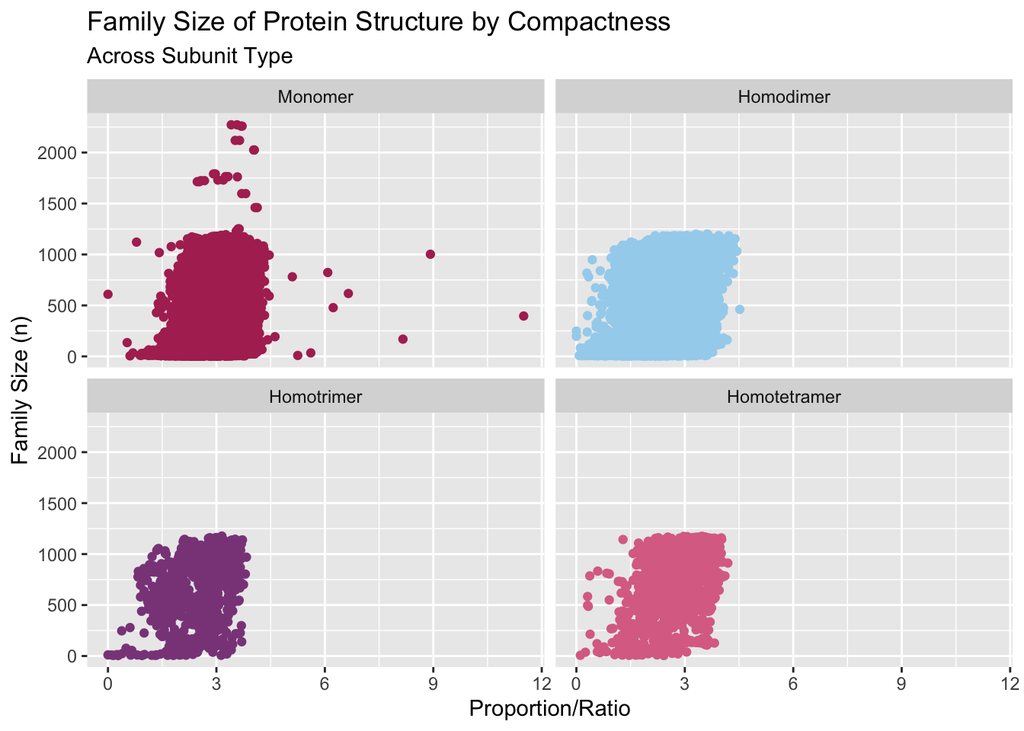

It does not appear that there is a linear relationship or association between compactness of protein structure and the family size of the protein structure for any of the subunit types.

##### Family Size by Intrasubunit Hydrogen Bonds

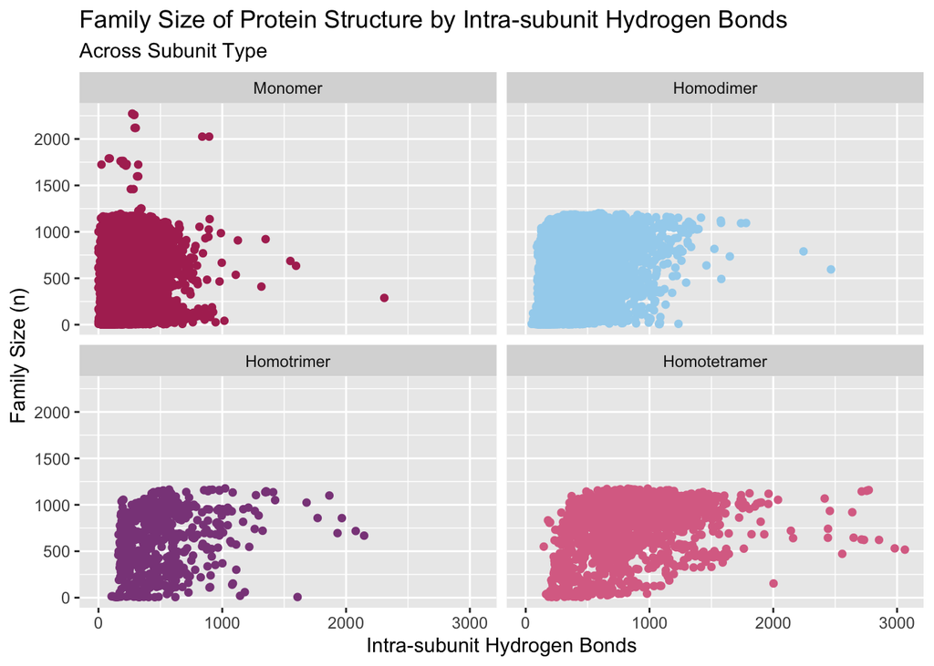

It does not appear that there is a linear relationship or association between the number of hydrogen bonds within a protein structure and the family size of the protein structure for any of the subunit types.

Because there does not seem to be any linear relationship or association between any of these variables and our predictor variable (`foldseek_family_size`, or family size of a protein structure), one next step we could do to analyze relationships *between* variables and thus predict trends, would be to evaluate the relationship of the *intersection* of these variables with family size of a protein structure!